# Webscraping example

Fernando Hernández Esquivel

16 de mayo de 2019

El ejemplo que aquí se desarrolla es sobre la lista del Patrimonio Mundial en Peligro compilada por la Organización de las Naciones Unidas para la Educación, la Ciencia y la Cultura (UNESCO),estos se determinaron en la convención que se estableció en 1972. A través de los datos de la página WIKIPEDIA se realizará un breve análisis gráfico. Para ir a la página de Wikipedia oprime en el siguiente [enlace](https://en.wikipedia.org/wiki/List_of_World_Heritage_in_Danger).

```r
library(stringr)
library(XML)
```

```r
library(maps)
library(RCurl)
library(rvest)
```

Se descarga el documento HTML de Wikipedia

```r
PM<-read_html("https://en.wikipedia.org/wiki/List_of_World_Heritage_in_Danger",asText = T,encoding = "UTF-8")
```

Se revisa la estructura del archivo

```r
str(PM)
```

```
## List of 2
##  $ node:<externalptr>
##  $ doc :<externalptr>
##  - attr(*, "class")= chr [1:2] "xml_document" "xml_node"
```

Se extraen las tablas del archivo y se revisa la estructura

```r
tablas<-html_table(PM,fill = T)
str(tablas)
```

```
## List of 5
##  $ :'data.frame':    2 obs. of  1 variable:
##   ..$ X1: chr [1:2] "Map this section's coordinates using: OpenStreetMap" "Download coordinates as: KML · GPX"
##  $ :'data.frame':    54 obs. of  9 variables:
##   ..$ Name         : chr [1:54] "Abu Mena" "Air and Ténéré Natural Reserves" "Ancient City of Aleppo" "Ancient City of Bosra" ...
##   ..$ Image        : logi [1:54] NA NA NA NA NA NA ...
##   ..$ Location     : chr [1:54] "EgyAbusir, Egypt30°50'30″N 29°39'50″E / 30.84167°N 29.66389°E / 30.84167;"| __truncated__ "Niger1Arlit Department, Niger18°17'N 8°0'E / 18.283°N 8.000°E / 18.283; 8.000 ("| __truncated__ "Aleppo Governorate,  Syria36°14'N 37°10'E / 36.233°N 37.167°E / 36.233; 37.1…
##   ..$ Criteria     : chr [1:54] "Cultural:(iv)" "Natural:(vii), (ix), (x)" "Cultural:(iii)(iv)" "Cultural:(i)(iii)(vi)" ...
##   ..$ Areaha (acre): chr [1:54] "182 (450)" "7,736,000 (19,120,000)" "350 (860)" "" ...
##   ..$ Year (WHS)   : int [1:54] 1979 1991 1986 1980 1979 2011 1982 1982 1982 2003 ...
##   ..$ Endangered   : chr [1:54] "2001" "1992" "2013" "2013" ...
##   ..$ Reason       : chr [1:54] "Cave-ins in the area caused by the clay at the surface, which becomes semi-liquid when met with \"excess water\"" "Military conflict and civil disturbance in the region as well as a reduction of wildlife population and degrada"| __truncated__ "Syrian Civil War, cu…
##   ..$ Refs         : chr [1:54] "[17][18][19]" "[20][21]" "[22]" "[23]" ...
##  $ :'data.frame':    2 obs. of  1 variable:
##   ..$ X1: chr [1:2] "Map this section's coordinates using: OpenStreetMap" "Download coordinates as: KML · GPX"
##  $ :'data.frame':    35 obs. of  9 variables:
##   ..$ Name         : chr [1:35] "Angkor" "Bagrati Cathedral and Gelati Monastery" "Bahla Fort" "Bam and its Cultural Landscape" ...
##   ..$ Image        : logi [1:35] NA NA NA NA NA NA ...
##   ..$ Location     : chr [1:35] "Siem Reap Province,  Cambodia13°26'N 103°50'E / 13.433°N 103.833°E / 13.433; 103.833 (Angkor)" "GeorImereti, Georgia42°15'44″N 42°42'59″E / 42.26222°N 42.71639°E / 42.26"| __truncated__ "Bahla,  Oman22°58'N 57°18'E / 22.967°N 57.300°E / 22.967; 57.300 (Bahla Fort)…
##   ..$ Criteria     : chr [1:35] "Cultural:(i), (ii), (iii), (iv)" "Cultural:(iv)" "Cultural:(iv)" "Cultural:(ii), (iii), (iv), (v)" ...
##   ..$ Areaha (acre): chr [1:35] "" "7.87 (19.4)" "" "" ...
##   ..$ Year (WHS)   : int [1:35] 1992 1994 1987 2004 1996 1992 1996 1983 1981 2004 ...
##   ..$ Endangered   : chr [1:35] "19922004" "20102017" "19882004" "20042013" ...
##   ..$ Reason       : chr [1:35] "Inscription initially limited to a three-year period (19931995) during which effective legal protection, bound"| __truncated__ "Major reconstruction project that will lead to irreversible interventions. The boundaries of the site was modif"| __truncated__ "Degrada…
##   ..$ Refs         : chr [1:35] "[110][111][112]" "[113][114][115]" "[116][117][118][119]" "[120][121][122]" ...
##  $ :'data.frame':    1 obs. of  3 variables:
##   ..$ vteLists of World Heritage Sites: chr "Africa\nAmericas\nNorth America\nCentral America\nCaribbean\nSouth America\nAsia\nEastern\nNorthern and Central"| __truncated__
##   ..$ vteLists of World Heritage Sites: chr "Africa\nAmericas\nNorth America\nCentral America\nCaribbean\nSouth America\nAsia\nEastern\nNorthern and Central"| __truncated__
##   ..$ vteLists of World Heritage Sites: logi NA
```

Interesa extraer la información de la lista 2, y revisar las variables que servirán para el análisis

```r
TabP<-TabP<-tablas[[2]]
names(TabP)
```

```
## [1] "Name"          "Image"         "Location"      "Criteria"
## [5] "Areaha (acre)" "Year (WHS)"    "Endangered"    "Reason"
## [9] "Refs"
```

Sólo se utilizan las variables de “Name”,“Location”(Ubicación geográfica),“Criteria”(Cultural-Natural),“Year (WHS)”(Año en que ingresó a la lista como patrimonio),“Endangered”(Año en que se determinó la categoría de “en peligro”) y se renombran

```r
TabP<-TabP[,c(1,3,4,6,7)]
colnames(TabP)<-c("nombre","ubicacion","categoria","año_lista","año_peligro")
str(TabP)
```

```
## 'data.frame':    54 obs. of  5 variables:
##  $ nombre     : chr  "Abu Mena" "Air and Ténéré Natural Reserves" "Ancient City of Aleppo" "Ancient City of Bosra" ...
##  $ ubicacion  : chr  "EgyAbusir, Egypt30°50'30″N 29°39'50″E / 30.84167°N 29.66389°E / 30.84167;"| __truncated__ "Niger1Arlit Department, Niger18°17'N 8°0'E / 18.283°N 8.000°E / 18.283; 8.000 ("| __truncated__ "Aleppo Governorate,  Syria36°14'N 37°10'E / 36.233°N 37.167°E / 36.233; 37.167 "| __tru…
##  $ categoria  : chr  "Cultural:(iv)" "Natural:(vii), (ix), (x)" "Cultural:(iii)(iv)" "Cultural:(i)(iii)(vi)" ...
##  $ año_lista  : int  1979 1991 1986 1980 1979 2011 1982 1982 1982 2003 ...
##  $ año_peligro: chr  "2001" "1992" "2013" "2013" ...
```

Se continua limpiando la variable “categoria” ya que contiene simbolos agregados

```r
TabP$categoria<-ifelse(str_detect(TabP$categoria,"Natural")==T,"natural","cultural")
TabP$categoria[1:4]
```

```
## [1] "cultural" "natural"  "cultural" "cultural"
```

Se sigue con la transformación de la variable año_lista

```r
TabP$año_lista<-as.numeric(TabP$año_lista)
TabP$año_lista[1:4]
```

```
## [1] 1979 1991 1986 1980
```

También se transforma la variable año_peligro

```r
año_limpio<-unlist(sub('.*(\\d{4}).*','\\1',TabP$año_peligro))
TabP$año_peligro<-as.numeric(año_limpio)
TabP$año_peligro[1:4]
```

```
## [1] 2001 1992 2013 2013
```

Para extraer la información que se necesita de la variable ubicación se emplea el siguiente código:

```r
reg_y<-"[/][ -]*[[:digit:]]*[.]*[[:digit:]]*[;]"
reg_x<-"[;][ -]*[[:digit:]]*[.]*[[:digit:]]*"
y_coords<-str_extract(TabP$ubicacion, reg_y)
y_coords<-as.numeric(str_sub(y_coords, 3, -2))
TabP$y_coords<-y_coords
x_coords<-str_extract(TabP$ubicacion, reg_x)
x_coords<-as.numeric(str_sub(x_coords, 3, -1))
TabP$x_coords <- x_coords
TabP$ubicacion <- NULL
TabP$y_coords<-round(TabP$y_coords,2)
TabP$x_coords<-round(TabP$x_coords,2)
dim(TabP)
```

```
## [1] 54  6
```

```r
head(TabP)
```

```
##                               nombre categoria año_lista año_peligro
## 1                           Abu Mena  cultural      1979        2001
## 2    Air and Ténéré Natural Reserves   natural      1991        1992
## 3             Ancient City of Aleppo  cultural      1986        2013
## 4              Ancient City of Bosra  cultural      1980        2013
## 5           Ancient City of Damascus  cultural      1979        2013
## 6 Ancient Villages of Northern Syria  cultural      2011        2013
##   y_coords x_coords
## 1    30.84    29.66
## 2    18.28     8.00
## 3    36.23    37.17
## 4    32.52    36.48
## 5    33.51    36.31
## 6    36.33    36.84
```

Una vez obtenidos los datos necesarios para el análisis se procederá a graficar los lugares en un mapa mundial

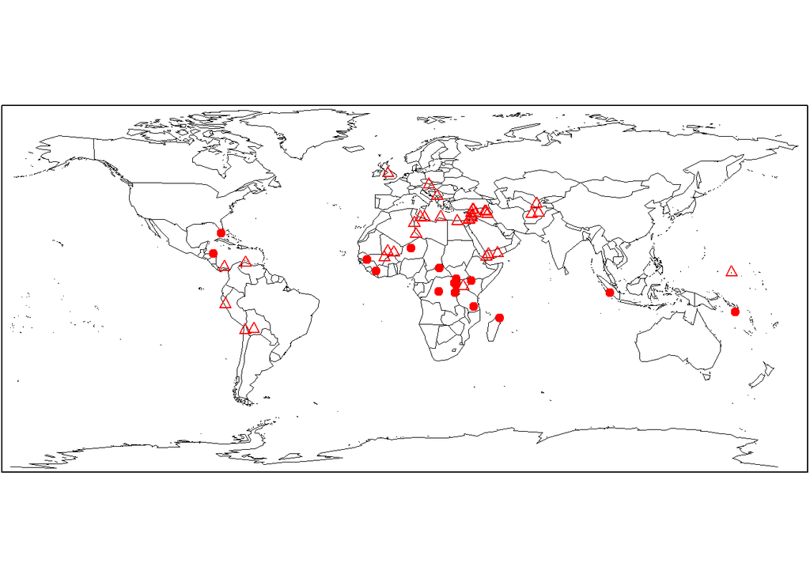

```r
pts<-ifelse(TabP$categoria=="natural",19,2)
map("world",col="black",lwd=0.5,mar=c(0.1, 0.1, 0.1, 0.1))
points(TabP$x_coords,TabP$y_coords, pch = pts,col="red")
box()
```

Es notable que la mayoria de los lugares se encuentran en el continente Africano

```r
table(TabP$categoria)
```

```
##
## cultural  natural
##       38       16
```

La mayoría de los lugares en peligro pertenecen a la categoría de lugares culturales

Despues se hace un histograma para poder observar la distribución de como fueron los lugares ingresando a la lista a través de tiempo

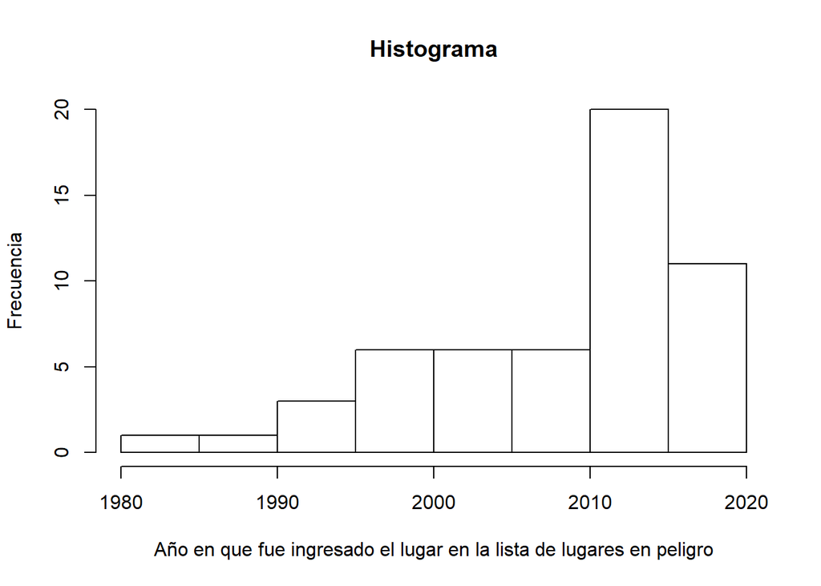

```r
hist(TabP$año_peligro,freq=T,xlab="Año en que fue ingresado el lugar en la lista de lugares en peligro",
     ylab="Frecuencia",main="Histograma")
```

Es interesante notar que en algunos lugares pasó menos de 1 año para que se ingresaran en la lista de lugares en peligro, también sería interesante saber ¿por qué apartir del año 2010 este fenómeno aumento considerablemente?

Aquí otro histograma con la distribución del tiempo que tomó a los sitios ser ingresados a la lista de lugares en peligro

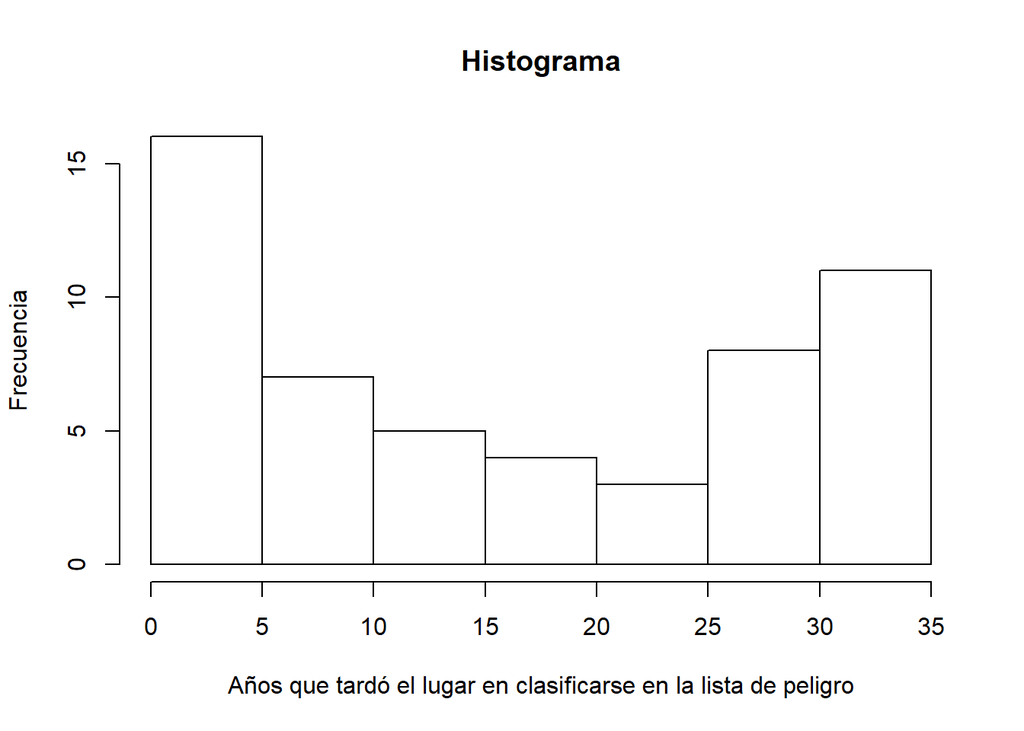

```r
duracion<-TabP$año_peligro-TabP$año_lista
hist(duracion,freq=TRUE,xlab="Años que tardó el lugar en clasificarse en la lista de peligro",ylab="Frecuencia",
     main = "Histograma")
```

Como se mencionó arriba, un mayor número de lugares fue ingresado a la lista de lugares peligrosos antes de los 5 años de haberse ingresado a la lista de patrimonio mundial. ¿Cuál es la razón de que esto suceda de esta manera?

Ejemplo reproducido del libro: Automated Data Collection with R,A Practical Guide to Web Scraping and Text Mining. Simon Munzert,Christian Rubba,Peter Meißner,Dominic Nyhuis